# Acoustic diversity indices as biodiversity indicators: a meta-analysis

Supplementary material

Irene Alcocer<sup>1</sup>, Herlander Lima<sup>2</sup> Larissa SM Sugai<sup>13</sup> and Diego Llusia<sup>13</sup> <sup>1</sup> Universidad Autónoma de Madrid, Spain <sup>2</sup> Universidad de Alcalá, Spain <sup>3</sup> Universidade Federal de Goiás, Brazil

```r
    require(knitr)
    require(png)
    require(dplyr)
    require(stringr)
    require(metafor)
    require(compute.es)
    require(MuMIn); eval(metafor:::.MuMIn)
    require(kableExtra)
    require(pander)
    require(ggplot2)
    require(RColorBrewer)

    source("src/acoustic_indices_functions.R")
```

This page describes the systematic review procedure and meta-analytic steps we took while assessing if acoustic indices are reliable indicators of biodiversity.

# Systematic review

We extensively searched existing literature for studies assessing the use of acoustic indices as proxies of biodiversity. The systematic search proceeded as follows:

1. We compiled studies that used acoustic diversity indices from four recent literature reviews on acoustic indices, biodiversity assessment and passive acoustic monitoring (i.e. (Sueur *et al.*, 2014; Buxton *et al.*, 2018a, 2018b; Sugai *et al.*, 2019)).
2. We updated the literature database from 2017 up to July 2019 with Thompson’s ISI Web of Science (WoS), querying the database for the keywords (i.e. bioacoustic∗ AND ind∗, ecoacoustic∗, acoustic∗ AND biodiversity, soundscape AND ecology). This search was restricted to 9 WoS subject areas (i.e., zoology, environmental sciences ecology, behavioural sciences, biodiversity conservation, marine freshwater biology, acoustics, evolutionary biology, entomology, and remote sensing).
3. Additionally, we used Google Scholar, to compile all literature from 2017 to July 2019 that cited the papers originally describing the eleven selected indices as well as literature that cited the recent papers published within this period.

Both peer-reviewed and no peer-reviewed studies were included to avoid publication bias.

After removing all duplicates, we gathered a total of 1,039 studies.

## Inclusion criteria

We considered studies eligible for meta-analysis if they met the following inclusion criteria:

- The study reported data to test the efficiency of acoustic diversity indices as indicators of biodiversity.
- The study provided statistical or graphical information of the direct relationship between biological diversity and acoustic diversity.
- We only considered studies using the 11 most common alpha acoustic indices (ACI, ADI, AEI, AR, BIO, ,H, Hf, Ht, M, NDSI, NP).

Following such inclusion criteria, we screened all selected studies (n = 1,039) based on their abstract, titles and keywords and thereby retaining 142 studies that were identified as potentially eligible. To ascertain their relevance, we conducted a full-text assessment on all these studies, finally retaining 35 studies that passed through all the criteria.

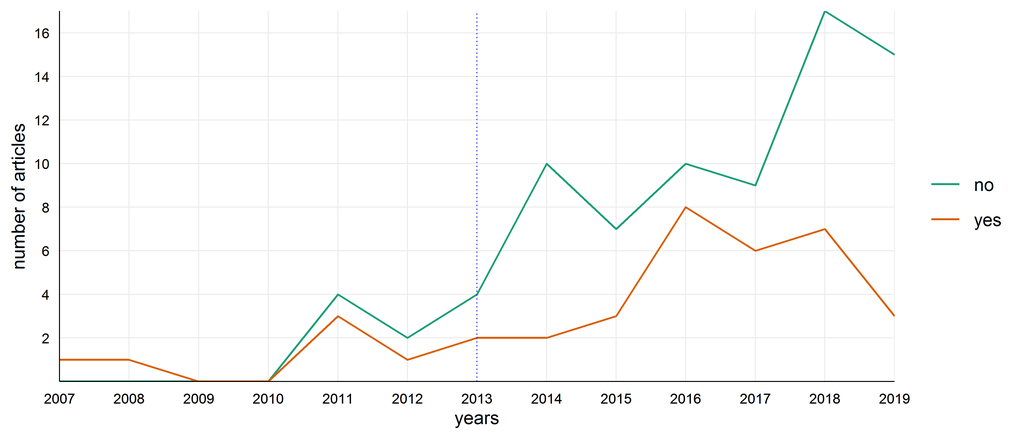

```r
knitr::include_graphics("rmd/Fig.S1.png")
```

**Supplementary Figure 1 -** Temporal evolution (2007 – 2019) of the validation data from the total of 142 articles. Articles which correlate the acoustic indices with real biological data are represented with an orange line and studies which do not correlate with a green line

## Data extraction

*Main extracted data*

For each study:

- We retrieved the acoustic indices calculated and related to biological diversity. The selected indices were: ACI, ADI, AEI, AR, BIO, H, Hf, Ht, M, NDSI, NP.
- We classified the diversity estimates that were measured and related to acoustic indices into five types: Abundance - number of individuals of a single or several species; Species richness - number of vocal and/or non-vocal species; Species diversity - Shannon index, Simpson index or species evenness; Sound abundance - number of sounds by known or unknown species.; Sound richness - number of sounds types by known or unknown species.
- We described the method applied to obtain such biological information based on two variables: Acoustic - data extracted from audio recordings; Non-acoustic - from sources other than recordings, i.e. literature, field surveys, etc.
- We included the environment type: Terrestrial; Aquatic.
- And studied taxonomic groups: Invertebrates; Anurans; Fish; Birds; Mammals; Several.

*Handling of pseudoreplication*

To account for differences in sampling effort among studies and to support the detection of cases of pseudoreplication that might potentially lead to biased statistical tests, we extensively assessed the study design by identifying a total of ten features that summarized both spatial and temporal sampling of each eligible study. When a mismatch between sample size and the number of true replicates was identified, we classified the analysis as using inflated replication and used true replicates as our sample size for meta-analysis.

## Effect size calculation

We used Pearson’s correlation coefficient r, as our measure of effect size. The effect size describes the magnitude of the relationship between acoustic indices and biodiversity. A positive correlation indicates a positive relationship between acoustic indices and biodiversity (i.e. a higher value for the acoustic index corresponds to higher biodiversity) whereas a negative correlation indicates a negative relationship between acoustic indices and biodiversity (i.e. a higher value for the acoustic index corresponds to lower biodiversity).

When Pearson’s correlation, r, could not be directly collected from the studies, we extracted other statistics, such as Spearman’s correlation, t-values, F-values, linear regression slope coefficients and R². If only graphical information was available we extracted the statistics with *Web Plot Digitizer v4.2.* (Rohatgi, 2019). We converted all statistics to r, using *compute.es* package in R (Del Re & Del Re, 2012) or when the package did not provide the needed functions we followed the formulas provided in Nakagawa & Cuthill (2007) and Koricheva, Gurevitch, & Mengersen (2013). Whenever study information was insufficient to compute the effect size, we contacted corresponding authors for missing data.

We converted our effect size r to Fisher’s Z in order to satisfy the normality assumption of parametric meta-analysis (Nakagawa & Cuthill, 2007). Fisher’s Z values were converted back to r, to ease interpretation of results.

## Dataset

We collected a total of 481 effect sizes from 35 studies. These number was reduced to 364 effect sizes and 34 studies, after computing composite effect sizes between non-independent effect sizes and removing a study due to difficulty in describing the study design.

```r
    df_raw <- read.csv("data/Table.S1.csv")
    n_used <- "n_adjusted"
    # Use n_adjusted as sample size
    df_tidy <- tidy_data(df_raw, n_used)
```

```
## Removed study id
##   54
## Dataframe aggregated from 481 to 364 entries
```

```r
    # Studies database
    studies <- read.csv("data/Table.S2.csv")
    df_tidy <- merge(df_tidy, studies, by.x = "id", by.y = "ID", all.x = TRUE)
    df_tidy <- df_tidy %>%
               mutate(authors = paste(Authors, year)) %>%
               select(id, entry, authors, everything(), -Publ_year, -Title,
                      -doi, -Authors)
```

**Supplementary Table 1 -** Complete dataset used in meta-analysis.

```r
kable(df_tidy, format = "html") %>%
     kable_styling(bootstrap_options = c("striped", "hover", "condensed")) %>%
     scroll_box(height = "400px", width = "100%")
```

| id | entry | authors | year | impact_factor | index | taxa | environ | bio | diversity_source | pseudoreplication | n | z | var | Journal |
| --- | --- | --- | --- | --- | --- | --- | --- | --- | --- | --- | --- | --- | --- | --- |
| 2 | 15 | Desjonquères et al. 2015 | 2015 | 2.180 | ACI | invertebrates | A | sound_abundance | acoustic | YES | 4 | 0.3285000 | 0.7500000 | PeerJ |
| 2 | 16 | Desjonquères et al. 2015 | 2015 | 2.180 | ACI | invertebrates | A | sound_richness | acoustic | YES | 4 | 0.3322500 | 0.7500000 | PeerJ |
| 2 | 17 | Desjonquères et al. 2015 | 2015 | 2.180 | AR | invertebrates | A | sound_abundance | acoustic | YES | 4 | 0.0692000 | 0.7500000 | PeerJ |
| 2 | 18 | Desjonquères et al. 2015 | 2015 | 2.180 | AR | invertebrates | A | sound_richness | acoustic | YES | 4 | 0.0851500 | 0.7500000 | PeerJ |
| 2 | 19 | Desjonquères et al. 2015 | 2015 | 2.180 | Hf | invertebrates | A | sound_abundance | acoustic | YES | 4 | -0.1851000 | 0.7500000 | PeerJ |
| 2 | 20 | Desjonquères et al. 2015 | 2015 | 2.180 | Hf | invertebrates | A | sound_richness | acoustic | YES | 4 | -0.1304000 | 0.7500000 | PeerJ |
| 2 | 21 | Desjonquères et al. 2015 | 2015 | 2.180 | Ht | invertebrates | A | sound_abundance | acoustic | YES | 4 | -0.3286500 | 0.7500000 | PeerJ |
| 2 | 22 | Desjonquères et al. 2015 | 2015 | 2.180 | Ht | invertebrates | A | sound_richness | acoustic | YES | 4 | -0.2970000 | 0.7500000 | PeerJ |
| 2 | 23 | Desjonquères et al. 2015 | 2015 | 2.180 | M | invertebrates | A | sound_abundance | acoustic | YES | 4 | 0.3453000 | 0.7500000 | PeerJ |
| 2 | 24 | Desjonquères et al. 2015 | 2015 | 2.180 | M | invertebrates | A | sound_richness | acoustic | YES | 4 | 0.3043500 | 0.7500000 | PeerJ |
| 2 | 25 | Desjonquères et al. 2015 | 2015 | 2.180 | NP | invertebrates | A | sound_abundance | acoustic | YES | 4 | 0.2074500 | 0.7500000 | PeerJ |
| 2 | 26 | Desjonquères et al. 2015 | 2015 | 2.180 | NP | invertebrates | A | sound_richness | acoustic | YES | 4 | 0.1851000 | 0.7500000 | PeerJ |
| 4 | 13 | Parks et al. 2014 | 2014 | 1.730 | H | mammals | A | sound_abundance | acoustic | YES | 4 | 0.2801000 | 0.7500000 | Ecol. Inform. |
| 6 | 1 | Boelman et al. 2007 | 2007 | 3.570 | BIO | birds | T | abundance | no_acoustic | NO | 8 | 1.5047000 | 0.2000000 | Ecol. Apli. |
| 9 | 44 | Harris et al. 2016 | 2016 | 5.710 | ACI | fish | A | diversity | no_acoustic | NO | 9 | 1.0278500 | 0.1250250 | Methods Ecol. Evol. |
| 9 | 45 | Harris et al. 2016 | 2016 | 5.710 | ACI | fish | A | richness | no_acoustic | NO | 9 | 0.2877000 | 0.1667000 | Methods Ecol. Evol. |
| 9 | 46 | Harris et al. 2016 | 2016 | 5.710 | AR | fish | A | diversity | no_acoustic | NO | 9 | 0.2104000 | 0.1250250 | Methods Ecol. Evol. |
| 9 | 47 | Harris et al. 2016 | 2016 | 5.710 | AR | fish | A | richness | no_acoustic | NO | 9 | 0.5361000 | 0.1667000 | Methods Ecol. Evol. |
| 9 | 48 | Harris et al. 2016 | 2016 | 5.710 | H | fish | A | diversity | no_acoustic | NO | 9 | 0.3258625 | 0.0937688 | Methods Ecol. Evol. |
| 9 | 49 | Harris et al. 2016 | 2016 | 5.710 | H | fish | A | richness | no_acoustic | NO | 9 | 0.6448500 | 0.1041875 | Methods Ecol. Evol. |
| 10 | 38 | Buscaino et al. 2016 | 2016 | 4.259 | ACI | fish | A | sound_abundance | acoustic | NO | 36 | 0.1003000 | 0.0303000 | Sci Rep |
| 10 | 39 | Buscaino et al. 2016 | 2016 | 4.259 | ACI | invertebrates | A | sound_abundance | acoustic | NO | 36 | 0.0000000 | 0.0303000 | Sci Rep |
| 10 | 170 | Buscaino et al. 2016 | 2016 | 4.259 | ACI | fish | A | sound_abundance | acoustic | NO | 36 | 0.8291000 | 0.0303000 | Sci Rep |
| 10 | 171 | Buscaino et al. 2016 | 2016 | 4.259 | ACI | invertebrates | A | sound_abundance | acoustic | NO | 36 | 0.1717000 | 0.0303000 | Sci Rep |
| 10 | 228 | Buscaino et al. 2016 | 2016 | 4.259 | ACI | fish | A | sound_abundance | acoustic | NO | 36 | 1.2562000 | 0.0303000 | Sci Rep |
| 10 | 229 | Buscaino et al. 2016 | 2016 | 4.259 | ACI | invertebrates | A | sound_abundance | acoustic | NO | 36 | 0.2132000 | 0.0303000 | Sci Rep |
| 10 | 276 | Buscaino et al. 2016 | 2016 | 4.259 | ACI | fish | A | sound_abundance | acoustic | NO | 36 | 0.9076000 | 0.0303000 | Sci Rep |
| 10 | 277 | Buscaino et al. 2016 | 2016 | 4.259 | ACI | invertebrates | A | sound_abundance | acoustic | NO | 36 | 0.1923000 | 0.0303000 | Sci Rep |
| 10 | 300 | Buscaino et al. 2016 | 2016 | 4.259 | ACI | fish | A | sound_abundance | acoustic | NO | 36 | 0.1206000 | 0.0303000 | Sci Rep |
| 10 | 301 | Buscaino et al. 2016 | 2016 | 4.259 | ACI | invertebrates | A | sound_abundance | acoustic | NO | 36 | 0.2554000 | 0.0303000 | Sci Rep |

[output cut: 334 more lines]

```r
vd <- data.frame(Variables = c("id", "entry", "journal", "year", "impact_factor", "index",
                               "taxa", "environ", "bio", "diversity_source", "pseudoreplication",
                               "n", "z", "var"),
                 Descriptions = c(
                      "Identification number for the study",
                      "Identification number for the effect size (row entry)",
                      "Journal where the study was published",
                      "Year of publication",
                      "Impact factor of the Journal",
                      "Acoustic index used",
                      "Primary studied group (invertebrates, fish, anurans, birds, mammals or several)",
                      "Ecosystem type where recordings were collected (A for Aquatic, T for terrestrial)",
                      "Diversity metric used to correlate with acoustic index values",
                      paste("Source of biological data. ",
                            "Sound recordings (coded as acoustic) or other source, ",
                            "i.e. literature, field surveys, etc. (coded as no_acoustic)."),
                      paste("Pseudoreplicated design to compute acoustic indices",
                            "relation with biodiversity (coded as YES). Coded as NO otherwise."),
                      "Sample size adjusted for what was considered the number of true replicates",
                      "Fisher's Z effect size",
                      "Fisher's Z variance"
             )
           )
pander(vd, justify = "left")
```

| Variables | Descriptions |
| --- | --- |
| id | Identification number for the study |
| entry | Identification number for the effect size (row entry) |
| journal | Journal where the study was published |
| year | Year of publication |
| impact_factor | Impact factor of the Journal |
| index | Acoustic index used |
| taxa | Primary studied group (invertebrates, fish, anurans, birds, mammals or several) |
| environ | Ecosystem type where recordings were collected (A for Aquatic, T for terrestrial) |
| bio | Diversity metric used to correlate with acoustic index values |
| diversity_source | Source of biological data. Sound recordings (coded as acoustic) or other source, i.e. literature, field surveys, etc. (coded as no_acoustic). |
| pseudoreplication | Pseudoreplicated design to compute acoustic indices relation with biodiversity (coded as YES). Coded as NO otherwise. |
| n | Sample size adjusted for what was considered the number of true replicates |
| z | Fisher’s Z effect size |
| var | Fisher’s Z variance |

## Dataset overview

In what follows, we give a brief overview of the dataset mostly by way of tables and figures.

Our dataset comprised a total of 34 studies and 364 effect sizes. Therefore, most studies contributed with more than one effect size for the meta-analysis.

**Supplementary Table 3 -** Number of effect sizes collected from each of the 34 studies included in the meta-analysis. ID corresponds to the study identification number in our dataset.

```r
studies_n <- as.data.frame(table(df_tidy$id), stringsAsFactors = FALSE)
studies_n <- cbind(unique(df_tidy$authors), studies_n)
colnames(studies_n) <- c("Study", "ID", "Effect_sizes")
studies_n <- studies_n %>%
              select(ID, Study, Effect_sizes) %>%
              arrange(-Effect_sizes)

kable(studies_n, format = "html") %>%
  kable_styling(c("striped"))
```

| ID | Study | Effect_sizes |
| --- | --- | --- |
| 2740 | Mammides et al. 2017 | 84 |
| 53 | Moreno-Gomez 2019 | 42 |
| 87 | Eldridge et al. 2018 | 28 |
| 80 | Staaterman et al. 2017 | 24 |
| 90 | Ferreira et al. 2018 | 24 |
| 96 | Izaguirre et al.Â 2018 | 24 |
| 10 | Buscaino et al. 2016 | 22 |
| 2 | DesjonquÃ¨res et al. 2015 | 12 |
| 11 | Bertucci et al. 2016 | 12 |
| 89 | Gage et al. 2017 | 12 |
| 2977 | Jorge et al. 2018 | 12 |
| 70 | Bolgan et al. 2018 | 11 |
| 9 | Harris et al. 2016 | 6 |
| 86 | Indraswari et al. 2018 | 6 |
| 427 | Fuller et al. 2015 | 6 |
| 14 | Wa Maina et al. 2016 | 4 |
| 60 | Patrick Lyon et al. 2019 | 4 |
| 77 | Fairbrass et al. 2017 | 4 |
| 92 | Torti et al. 2018 | 4 |
| 15 | Roca & Proulx 2016 | 3 |
| 45 | McLaren 2012 | 3 |
| 13 | McWilliam & Hawkin 2013 | 2 |
| 41 | Paisley-Jones 2011 | 2 |
| 44 | Machado et al. 2017 | 2 |
| 251 | Buxton et al. 2016 | 2 |
| 4 | Parks et al. 2014 | 1 |
| 6 | Boelman et al. 2007 | 1 |
| 17 | Zhang et al. 2015 | 1 |
| 37 | Picciulin et al. 2016 | 1 |
| 1132 | Depraetere et al. 2012 | 1 |
| 1177 | Joo et al. 2011 | 1 |
| 1262 | Pieretti et al. 2011 | 1 |
| 2745 | Sueur et al. 2008 | 1 |
| 2986 | Raynor et al. 2017 | 1 |

The most studied acoustic index was ACI and the most used biodiversity metric was ‘species richness’.

**Supplementary Table 4 -** Number of effect sizes and studies per moderator levels.

```r
# Table for moderator levels
mods <- c("index", "bio", "diversity_source", "environ")
sample_sizes <- do.call(rbind, lapply(mods, function(x) n_studies_entries(df_tidy, x)))
# Format output
sample_sizes <- cbind(row.names(sample_sizes), sample_sizes)
sample_sizes <- as.data.frame(sample_sizes)
names(sample_sizes) <- c("Moderator_levels", "Effect_sizes", "Studies")
sample_sizes$Moderator_levels <- str_replace(sample_sizes$Moderator_levels, "^([a-z])", toupper)
n_row <- nrow(sample_sizes)
sample_sizes$Moderator_levels[(n_row - 1):n_row] <- c("Aquatic", "Terrestrial")

kable(sample_sizes, format = "html", row.names = FALSE) %>%
    kable_styling("striped", full_width = FALSE, position = "left") %>%
    row_spec(0, font_size = 16, bold = TRUE) %>%
    pack_rows("Acoustic indices", 1, 11) %>%
    pack_rows("Biodiversity metrics", 12, 16) %>%
    pack_rows("Diversity source", 17, 18) %>%
    pack_rows("Environment", 19, 20)
```

| Moderator_levels | Effect_sizes | Studies |
| --- | --- | --- |
| **Acoustic indices** |  |  |
| ACI | 113 | 25 |
| ADI | 38 | 12 |
| AEI | 34 | 8 |
| AR | 18 | 5 |
| BIO | 36 | 10 |
| H | 55 | 16 |
| Hf | 12 | 3 |
| Ht | 15 | 4 |
| M | 5 | 2 |
| NDSI | 33 | 10 |
| NP | 5 | 2 |
| **Biodiversity metrics** |  |  |
| Abundance | 27 | 6 |
| Diversity | 49 | 9 |
| Richness | 187 | 21 |
| Sound_abundance | 66 | 11 |
| Sound_richness | 35 | 3 |
| **Diversity source** |  |  |
| Acoustic | 200 | 26 |
| No_acoustic | 164 | 11 |
| **Environment** |  |  |
| Aquatic | 95 | 10 |
| Terrestrial | 269 | 24 |

### Visual description of eligible studies

We gathered studies from 6 of the 7 continents (no studies in Antarctica). Most studies were conducted in USA, France, Australia and Brazil.

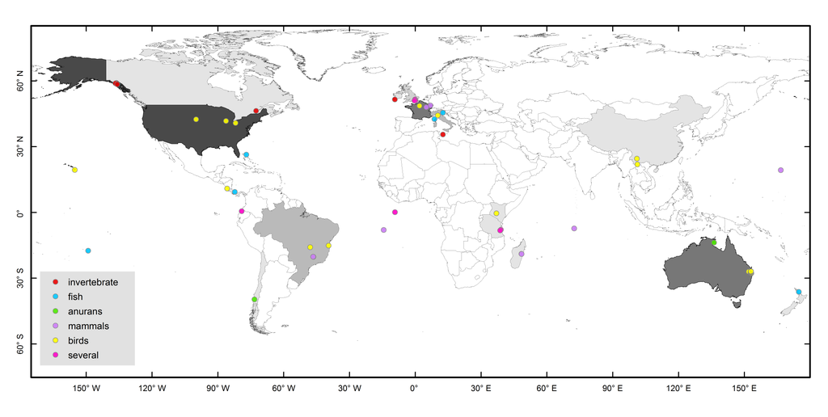

```r
knitr::include_graphics("rmd/mapa.png")
```

**Supplementary Figure 2 -** The geographic distribution of the study sites corresponding to the 35 studies used in meta-analysis. The coloring of countries exhibits a white to black gradient relative to an increase in the number of studies contributed by each country. The colored dots discriminate between different groups of studied taxon.

The performance of acoustic indices as a biodiversity indicators was mainly assessed with species richness and sound abundance as biodiversity metrics.

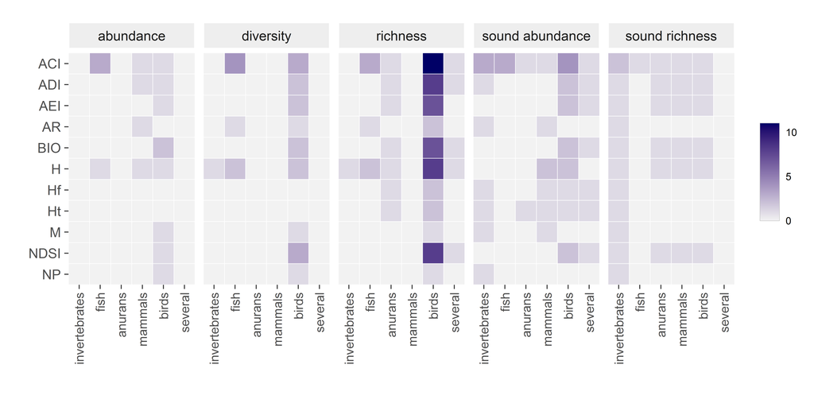

```r
knitr::include_graphics("rmd/heatmap.png")
```

**Supplementary Figure 3 -** Distribution of the 35 articles by biodiversity parameters, taxa and acoustic indices studied. The graph shows the number of articles for each biodiversity parameter and taxonomic group for the each acoustic indices.

A large set of studies (40%) exhibited statistical deficiencies in testing the relationship between acoustic indices and biodiversity estimates due to pseudoreplication.

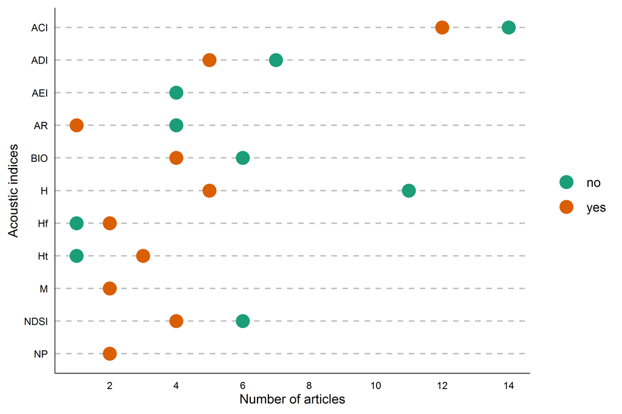

```r
knitr::include_graphics("rmd/ps.index.png")
```

**Supplementary Figure 4 -** Pseudoreplication summary. The data is representing the total number of articles for each index. Color orange represents number of pseudo-replicated studies and green non pseudo-replicated studies. The article (Papin et al., 2019b) was withdrawal from the pseudoreplication analysis due to impossibility of obtain the pseudoreplication data causing some variation on the total number of each acoustic index..

# Meta-analysis

We clustered effect sizes within their corresponding studies and conducted multilevel meta-analysis using Fisher’s Z as our response variable. The multilevel structure accounted for the correlation structures within studies and thus allowed the inclusion of multiple effect sizes per study.

## Summary effect size

We tested whether acoustic indices were good estimators of biodiversity by computing an intercept-only model. The resulting summary effect size not only gives a clue of whether acoustic indices are performing well in estimating biodiversity across the literature, but also allows us to check if there is substantial heterogeneity in our effect sizes that could be explained by moderators.

*Intercept-only meta-analysis output*

```r
res_main <- rma.mv(z, var, random = ~1 | id/entry, data = df_tidy)
res_main
```

```
##
## Multivariate Meta-Analysis Model (k = 364; method: REML)
##
## Variance Components:
##
##             estim    sqrt  nlvls  fixed    factor
## sigma^2.1  0.0458  0.2139     34     no        id
## sigma^2.2  0.1755  0.4190    364     no  id/entry
##
## Test for Heterogeneity:
## Q(df = 363) = 2220.9097, p-val < .0001
##
## Model Results:
##
## estimate      se    zval    pval   ci.lb   ci.ub
##   0.3461  0.0577  6.0014  <.0001  0.2331  0.4591  ***
##
## ---
## Signif. codes:  0 '***' 0.001 '**' 0.01 '*' 0.05 '.' 0.1 ' ' 1
```

**Supplementary Table 5 -** Resulting estimates from intercept-only model converted to Pearson’s correlation. “Estimate” is the Pearson’s r summary effect size. “CI.lb” and “CI.ub” are the confidence intervals lower and upper bounds, respectively.

```r
r_main <- sapply(c(r = res_main$b, CI.lb = res_main$ci.lb, CI.ub = res_main$ci.ub), z2r)
r_main_pander <- r_main
names(r_main_pander) <- c("Estimate", names(r_main)[2:3])
pander(r_main_pander)
```

| Estimate | CI.lb | CI.ub |
| --- | --- | --- |
| 0.3329 | 0.2289 | 0.4294 |

The summary estimate indicates that acoustic indices showed a moderate correlation with biodiversity metrics. However this result does not say nothing about differences in performance between acoustic indices or context-dependencies due to, for example, different environments or diversity metrics. For this we would need to inspect moderators, but before we need to check if our intercept-only model has unexplained variance that can be partitioned by our chosen moderators.

### Effect sizes in ascending order

The amount of heterogeneity in effect sizes can be coarsely inspected by plotting all effect sizes and respective variances, and see their dispersion along the x-axis.

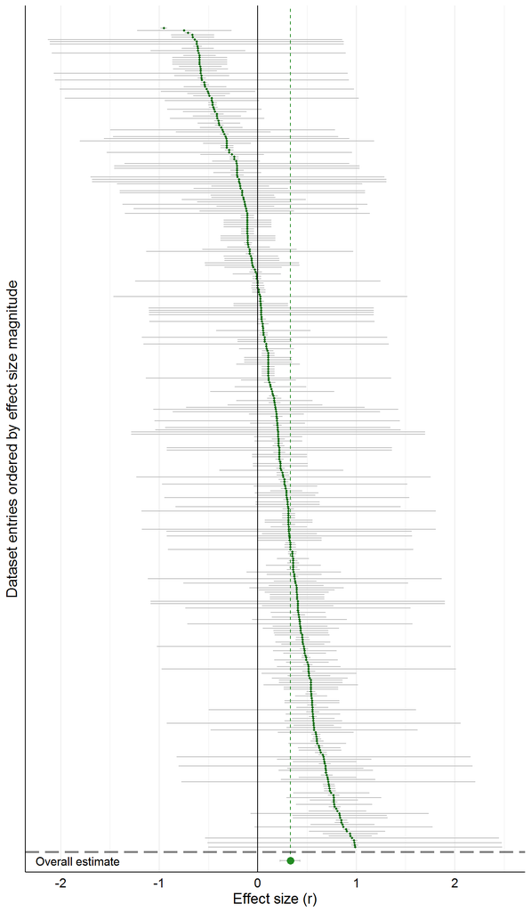

```r
df_all_plt <- mutate(df_tidy, z = z2r(z), var = z2r(var))
r_main <- as.data.frame(t(r_main))
nudge <- 2
overall_y <- -nudge - 1
ggplot(data = df_all_plt, aes(x = z, y = reorder(entry, -z))) +
    geom_errorbarh(aes(xmin = z - 1.96 * var, xmax = z + 1.96 * var),
                   height = 0, size = 0.5, color = "grey",
                   position = position_nudge(y = nudge)) +
    geom_point(size = 0.8, color = "darkgreen",
               position = position_nudge(y = nudge)) +
    geom_segment(aes(x = z2r(res_main$b), y = overall_y,
                     xend = z2r(res_main$b),
                     yend = nrow(df_all_plt) + nudge + 10),
                     color = alpha("forestgreen", 0.7), linetype = 2, size = 0.5) +
    geom_vline(xintercept = 0, linetype = 1) +
    # Insert overall estimate
    geom_errorbarh(aes(xmin = r_main$CI.lb, xmax = r_main$CI.ub, y = overall_y),
                   color = "grey") +
    geom_point(data = r_main, aes(x = r, y = overall_y), size = 3, color = "forestgreen") +
    geom_hline(yintercept = nudge - 1, color = alpha("black", 0.5), linetype = 5, size = 1) +
    annotate("text", x = -1.4, y = overall_y, label= "Overall estimate", size = 4, adj = "right") +
    scale_y_discrete(expand = c(0.025, 0.01)) +
    xlab("Effect size (r)") +
    ylab("Dataset entries ordered by effect size magnitude") +
    theme_minimal() +
    theme(axis.text.x = element_text(size = 12, color = "black"),
          axis.text.y = element_blank(),
          axis.line.x = element_line(color = "black"),
          axis.line.y = element_line(color = "black"),
          axis.title = element_text(size = 14),
          panel.grid.major.y = element_blank(),
          legend.position = "none"
    )
```

**Figure 4a -** Pearson correlation effect sizes (r) in ascending order of magnitude from all dataset entries. Effect sizes higher than 0 (vertical line) represent a positive correlation between acoustic indices and diversity. Effect sizes below 0 indicate a negative correlation between acoustic indices and diversity. The green circles above the dashed horizontal line, are effect sizes means and corresponding 95% confidence intervals (grey horizontal lines). Below the dashed line is the summary effect size (green circle) and corresponding 95% confidence interval (grey horizontal lines) obtained after running the intercept-only model.

### Check heterogeneity

We quantified heterogeneity with the I² statistic, which estimates the proportion of unknown variation in effect sizes not attributed to sampling error variance.

**Supplementary Table 6 -** Unnacounted heterogeneity of the intercept-only model as measured by I<sup>2</sup> statistic. Within study heterogeneity (level 2) corresponds to the unnacounted variation that is found on effect sizes within studies, and between study heterogeneity corresponds to the unnacounted variation between studies (level 3).

```r
font_css <- "font-family: Arial"
Is <- multilevel_I(res_main) * 100
Is_df <- data.frame(Is[1], Is[2])
names(Is_df) <- c("Within study", "Between study")
rownames(Is_df) <- c("% Unexplained variation")
total_I <- paste("Total heterogeneity: ", round(Is[1] + Is[2], 2), "%")
header <- c(3)
names(header) <- c(total_I)
kable(Is_df, format = "html", digits = 2) %>%
  kable_styling(c("striped", "bordered"), full_width = FALSE,
                position = "center") %>%
  add_header_above(header, font_size = 16, bold = TRUE,
                   extra_css = font_css) %>%
  row_spec(0, font_size = 14, extra_css = font_css) %>%
  row_spec(1, font_size = 12, align = "center")
```

| Total heterogeneity: 85.13 % | Total heterogeneity: 85.13 % Within study | Total heterogeneity: 85.13 % Between study |
| --- | --- | --- |
| % Unexplained variation | 17.61 | 67.52 |

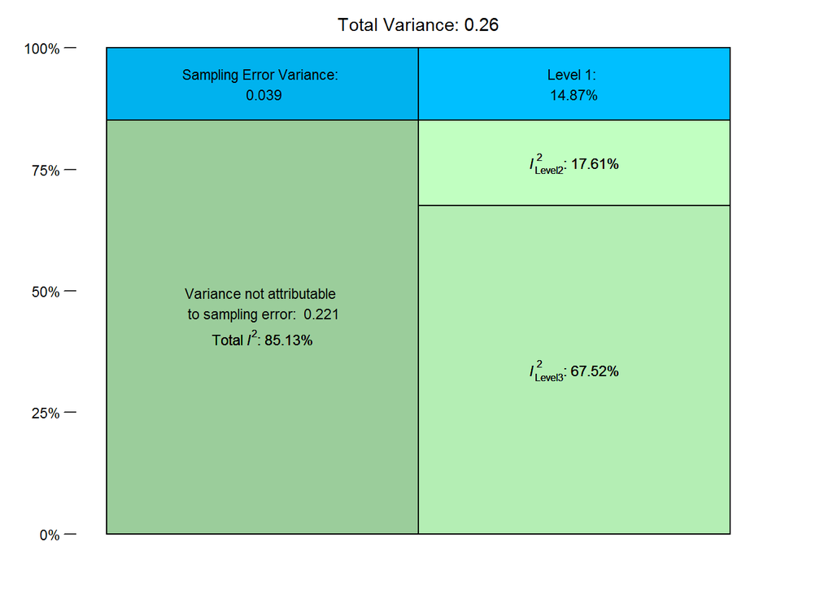

```r
mlm.variance.distribution(res_main)
```

**Supplementary Figure 5 -** Visual representation of how variance was distributed over the multilevel structure of the intercept-only model. Within study heterogeneity (level 2) corresponds to the unnacounted variation that is found on effect sizes within studies, and between study heterogeneity corresponds to the unnacounted variation between studies (level 3).

The value of I<sup>2</sup> = 85% corresponding to the amount of heterogeneity that remains unnacounted for in the intercept-only model, gives a green signal to proceed with the use of moderators that can potentially explain some of this variation.

## Analysis of moderators

We extended the previous intercept-only model with the inclusion of moderators as fixed factors. For these analysis, all moderator levels with less than 5 studies were excluded as low study sizes are more liable to produce biased estimates. This led to the removal of the acoustic indices ‘Hf’, ‘Ht’, ‘M’ and ‘NP’, and the biodiversity parameter ‘sound richness’ from model fitting procedures.

### Sub-group analysis

We conducted sub-group analysis with acoustic index as a moderator to assess which acoustic indices best correlate with biodiversity.

To specifically test whether the effect size estimates from each acoustic index were different from zero we removed the model intercept.

```r
df_indices <-  clear_moderators(df_tidy, "index")
```

```
## Levels dropped from dataframe:
##  Moderator index
##       Hf Ht M NP
```

*Meta-analysis output with acoustic indices as moderator and no intercept.*

```r
res_indices <- rma.mv(z, var, random = ~ 1 | id/entry, mods = ~ index - 1, data = df_indices)
res_indices
```

```
##
## Multivariate Meta-Analysis Model (k = 327; method: REML)
##
## Variance Components:
##
##             estim    sqrt  nlvls  fixed    factor
## sigma^2.1  0.0295  0.1716     34     no        id
## sigma^2.2  0.1710  0.4135    327     no  id/entry
##
## Test for Residual Heterogeneity:
## QE(df = 320) = 1876.0325, p-val < .0001
##
## Test of Moderators (coefficients 1:7):
## QM(df = 7) = 70.5454, p-val < .0001
##
## Model Results:
##
##            estimate      se    zval    pval    ci.lb   ci.ub
## indexACI     0.3809  0.0685  5.5596  <.0001   0.2466  0.5152  ***
## indexADI     0.2493  0.0977  2.5506  0.0108   0.0577  0.4408    *
## indexAEI     0.0396  0.1048  0.3774  0.7059  -0.1658  0.2449
## indexAR      0.0780  0.1354  0.5756  0.5649  -0.1875  0.3434
## indexBIO     0.1950  0.1012  1.9266  0.0540  -0.0034  0.3934    .
## indexH       0.5511  0.0903  6.1036  <.0001   0.3742  0.7281  ***
## indexNDSI    0.4557  0.1037  4.3944  <.0001   0.2524  0.6589  ***
##
## ---
## Signif. codes:  0 '***' 0.001 '**' 0.01 '*' 0.05 '.' 0.1 ' ' 1
```

**Supplementary Table 7 -** Resulting estimates from sub-group analysis. The ‘Estimate’ column is the Pearson correlation effect size; SE is the standard error and CI.lb and CI.up, the lower and upper bounds of the confidence intervals, respectively.

```r
df_pred_indices <- get_predictions(res_indices, intercept = FALSE)
df_pred_indices$coef <- str_remove(df_pred_indices$coef, "index")
names(df_pred_indices) <- c("Index", "Estimate", "SE", "CI.lb", "CI.ub")
pander(df_pred_indices)
```

| Index | Estimate | SE | CI.lb | CI.ub |
| --- | --- | --- | --- | --- |
| ACI | 0.363 | 0.068 | 0.242 | 0.474 |
| ADI | 0.244 | 0.097 | 0.058 | 0.414 |
| AEI | 0.04 | 0.104 | -0.164 | 0.24 |
| AR | 0.078 | 0.135 | -0.185 | 0.331 |
| BIO | 0.193 | 0.101 | -0.003 | 0.374 |
| H | 0.501 | 0.09 | 0.358 | 0.622 |
| NDSI | 0.427 | 0.103 | 0.247 | 0.578 |

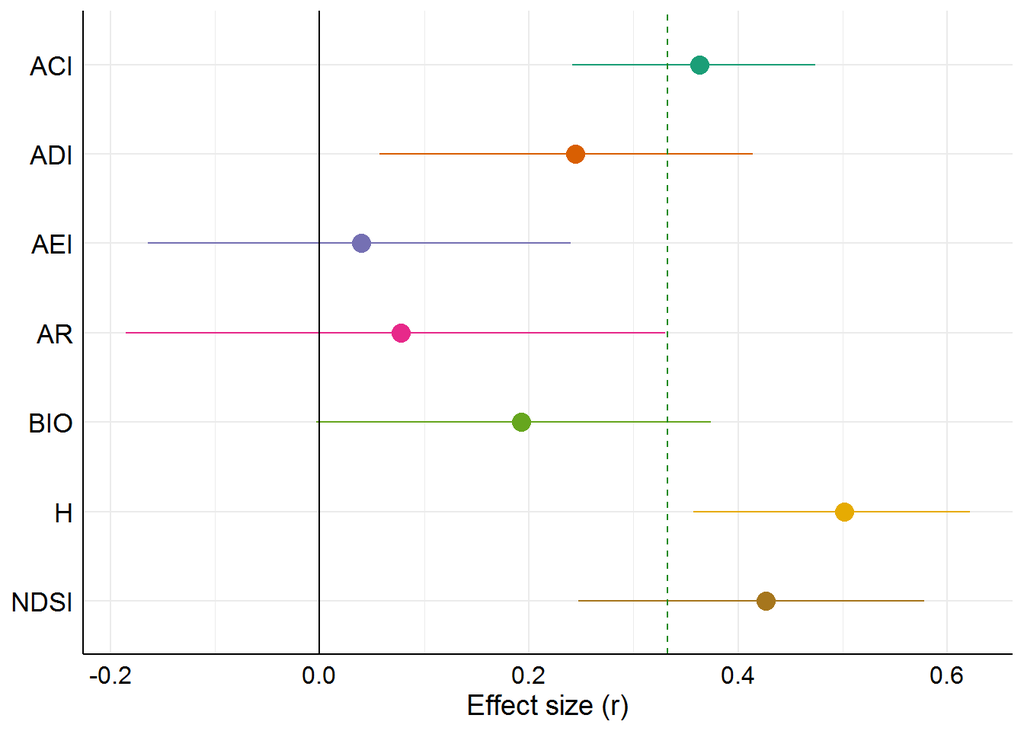

```r
nentries_index <- rowSums(table(df_indices$index, df_indices$id))
nstudies_index <- rowSums(ifelse(table(df_indices$index, df_indices$id) > 0, 1, 0))
n_index <- paste0(nentries_index, " (", nstudies_index, ")")

df_indices_plt <- data.frame("index" = names(nstudies_index),
                             "es" = z2r(res_indices$beta),
                             "se" = z2r(res_indices$se),
                             "ci.lb" = z2r(res_indices$ci.lb),
                             "ci.ub" = z2r(res_indices$ci.ub),
                             "n" = nstudies_index)

ggplot(data = df_indices_plt, aes(x = es, y = index)) +
    geom_point(aes(color = index), size = 4) +
    geom_errorbarh(aes(xmin = ci.lb, xmax = ci.ub, color= index),
                   height = 0) +
    geom_vline(xintercept = 0, linetype = 1) +
    geom_vline(xintercept = z2r(res_main$b), color = "forestgreen",
               linetype = 2) +
    scale_y_discrete(limits = rev(df_indices_plt$index)) +
    scale_color_brewer(palette="Dark2") +
    theme_minimal() +
    xlab("Effect size (r)") +
    theme(axis.text.x = element_text(size = 12, color = "black"),
          axis.text.y = element_text(size = 13, color = "black"),
          axis.line.x = element_line(color = "black"),
          axis.line.y = element_line(color = "black"),
          axis.title.x = element_text(size = 14),
          axis.title.y = element_blank(),
          legend.position = "none"
    )
```

**Figure 4b -** Effect size mean estimates (circles) and corresponding 95% confidence intervals (horizontal lines) obtained from sub-group meta-analysis with acoustic indices as the grouping factor. Estimated effect sizes whose 95% confidence intervals do not overlap zero (black vertical line) indicate a positive correlation between acoustic indices and diversity if they are to the right of zero, or a negative correlation if they are to the left of zero. The dashed green vertical line represents the summary effect size obtained from the intercept only meta-analysis.

### Meta-regression

We used meta-regression to check the effect of multiple moderators on the ability of acoustic indices to estimate biodiversity. We focused on four moderators that could alter the performance of biodiversity estimation, namely:

1. acoustic index - which acoustic index was used to estimate biodiversity;
2. biodiversity metrics – which metric of diversity was used to check the performance of acoustic index;
3. environment – if recordings were done in aquatic or terrestrial environments;
4. diversity source – if metric of diversity was obtained from examination of sound recordings of any other source (e.g. field sampling).

We set as intercept the following combination of moderator levels: ACI index, species richness, terrestrial environment and non-acoustic data source.

Due to low study sample size between most factor level combinations, we were constrained to use only an additive effects model.

```r
mods <- c("index", "bio", "environ", "diversity_source")
df_full <- clear_moderators(df_tidy, mods)
```

```
## Levels dropped from dataframe:
##  Moderator index
##       Hf Ht M NP
##  Moderator bio
##       sound_richness
##  Moderator environ
##
##  Moderator diversity_source
##
```

*Meta-analysis with acoustic indices, biodiversity metrics, environment and diversity source as moderators.*

```r
res_full <- rma.mv(z, var, random = ~1 | id/entry,
                   mods = ~ index + bio + environ + diversity_source,
                   data = df_full)

res_full
```

```
##
## Multivariate Meta-Analysis Model (k = 296; method: REML)
##
## Variance Components:
##
##             estim    sqrt  nlvls  fixed    factor
## sigma^2.1  0.0355  0.1884     33     no        id
## sigma^2.2  0.1738  0.4168    296     no  id/entry
##
## Test for Residual Heterogeneity:
## QE(df = 284) = 1730.2577, p-val < .0001
##
## Test of Moderators (coefficients 2:12):
## QM(df = 11) = 27.4277, p-val = 0.0040
##
## Model Results:
##
##                           estimate      se     zval    pval    ci.lb    ci.ub
## intrcpt                     0.3590  0.1416   2.5359  0.0112   0.0815   0.6365
## indexADI                   -0.1294  0.1171  -1.1049  0.2692  -0.3590   0.1001
## indexAEI                   -0.2916  0.1231  -2.3679  0.0179  -0.5329  -0.0502
## indexAR                    -0.2735  0.1482  -1.8461  0.0649  -0.5639   0.0169
## indexBIO                   -0.1449  0.1203  -1.2038  0.2287  -0.3807   0.0910
## indexH                      0.1977  0.1092   1.8111  0.0701  -0.0162   0.4117
## indexNDSI                   0.0840  0.1260   0.6667  0.5050  -0.1630   0.3310
## bioabundance               -0.0815  0.1589  -0.5133  0.6078  -0.3929   0.2298
## biodiversity               -0.0420  0.0950  -0.4423  0.6583  -0.2283   0.1442
## biosound_abundance          0.2600  0.1470   1.7690  0.0769  -0.0281   0.5480
## environA                   -0.0656  0.1484  -0.4422  0.6583  -0.3565   0.2252
## diversity_sourceacoustic   -0.0091  0.1464  -0.0623  0.9504  -0.2962   0.2779
##
## intrcpt                   *
## indexADI
## indexAEI                  *
## indexAR                   .
## indexBIO
## indexH                    .
## indexNDSI
## bioabundance
## biodiversity
## biosound_abundance        .
## environA
## diversity_sourceacoustic
##
## ---
## Signif. codes:  0 '***' 0.001 '**' 0.01 '*' 0.05 '.' 0.1 ' ' 1
```

#### **Multicollinearity**

Multicollinearity among our moderators was inspected with VIF and found not to be an issue in our model (VIF < 1.7 for all moderators – threshold value of 3 (Zuur, Ieno, & Elphick, 2010).

**Supplementary Table 8 -** VIF values obtained for each moderator level.

```r
vif_meta <- as.data.frame(vif.rma(res_full))
vif_meta <- tibble::rownames_to_column(vif_meta, "Moderators")
colnames(vif_meta)[2] <- "VIF"
pander(vif_meta)
```

| Moderators | VIF |
| --- | --- |
| indexADI | 1.497 |
| indexAEI | 1.45 |
| indexAR | 1.25 |
| indexBIO | 1.478 |
| indexH | 1.472 |
| indexNDSI | 1.438 |
| bioabundance | 1.244 |
| biodiversity | 1.156 |
| biosound_abundance | 1.454 |
| environA | 1.393 |
| diversity_sourceacoustic | 1.623 |

#### **Heterogeneity full model**

Substantial heterogeneity remained to be explained after fitting the full model. So other factors not tested or an interaction among our moderators could have the ability to extract even more information from the dataset. For the latter, an increase in available studies on the correlation between acoustic indices and biodiversity is of the utmost important.

```r
# Fit overall model with df_full (without levels with less than 5 studies)
res_main_full <- rma.mv(z, var, random = ~1 | id/entry, data = df_full)
sum_I_main_full <- sum(multilevel_I(res_main_full))
sum_I_full <- sum(multilevel_I(res_full))

cat("Heterogenity after fitting the full model\n\t", sum_I_full, "\n\n",
    "Difference heterogeneity between intercept only model and full model\n\t",
    sum_I_main_full - sum_I_full)
```

```
## Heterogenity after fitting the full model
##   0.8616913
##
##  Difference heterogeneity between intercept only model and full model
##   0.01210371
```

#### **Full model results**

**Supplementary Table 9 -** Meta-regression results. The column “Coefficients” lists the model intercept and the levels of each moderator. The column “Estimate” is the estimated Pearson (r) correlation. “SE” is the standard error of the estimate. “CI” are the [lower] [upper] bounds of the confidence intervals.

```r
df_pred_tbl <- get_predictions(res_full, format_table = TRUE, clean_labels = TRUE)
pander(df_pred_tbl)
```

| Moderators | Coefficients | Estimate | SE | CI |
| --- | --- | --- | --- | --- |
| Intercept | Intercept | 0.344 | 0.141 | [0.081] [0.563] |
| Index | ADI | 0.226 | 0.147 | [-0.061] [0.478] |
| Index | AEI | 0.067 | 0.152 | [-0.228] [0.351] |
| Index | AR | 0.085 | 0.17 | [-0.246] [0.399] |
| Index | BIO | 0.211 | 0.149 | [-0.08] [0.469] |
| Index | H | 0.506 | 0.14 | [0.273] [0.682] |
| Index | NDSI | 0.416 | 0.148 | [0.15] [0.626] |
| Bio | Abundance | 0.271 | 0.164 | [-0.047] [0.539] |
| Bio | Diversity | 0.307 | 0.144 | [0.033] [0.537] |
| Bio | Sound abundance | 0.55 | 0.211 | [0.197] [0.777] |
| Environment | Aquatic | 0.285 | 0.142 | [0.012] [0.519] |
| Source | Acoustic | 0.336 | 0.108 | [0.136] [0.51] |

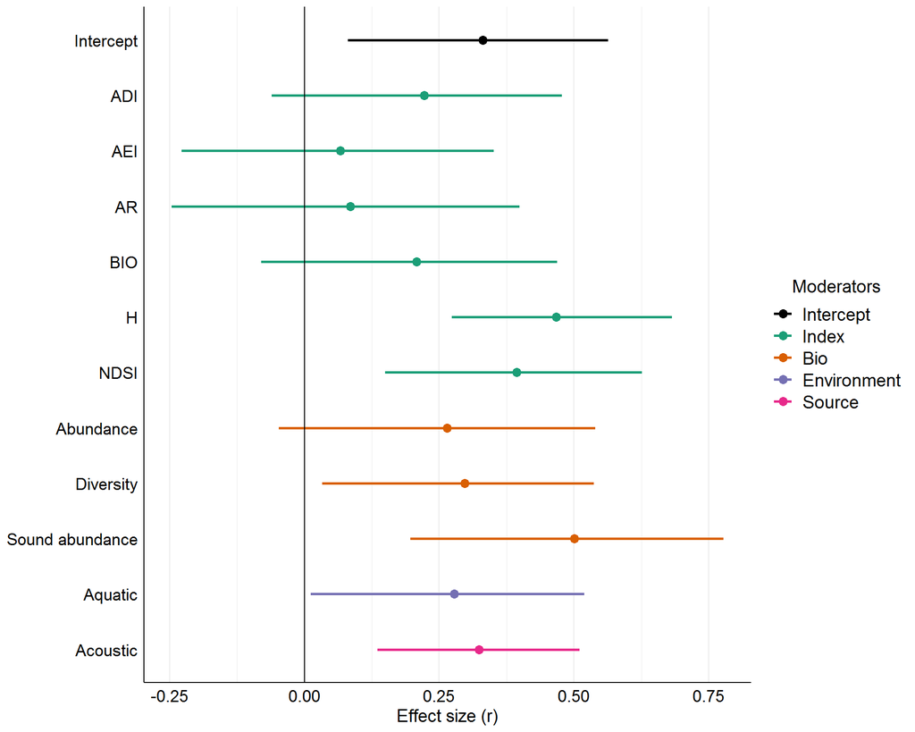

```r
df_pred <- get_predictions(res_full)
colnames(df_pred) <- tolower(str_remove(colnames(df_pred), "\\s.*"))
df_pred$moderators <- df_pred_tbl$Moderators
df_pred$coef <- factor(df_pred_tbl$Coefficients,
                       levels = rev(df_pred_tbl$Coefficients))

plt_colors <- c("#000000", brewer.pal(n = 4, name = "Dark2"))
ggplot(data = df_pred, aes(x = z2r(estimate), y = coef, color = moderators)) +
    geom_point(size = 3) +
    geom_errorbarh(aes(xmin = ci.lb, xmax = ci.ub), height = 0, size = 1) +
    geom_vline(xintercept = 0, linetype = 1) +
    scale_color_manual(values = plt_colors, name = "Moderators") +
    theme_minimal() +
    xlab("Effect size (r)") +
    theme(axis.text.x = element_text(size = 13, color = "black"),
          axis.text.y = element_text(size = 13, color = "black"),
          axis.line.x = element_line(color = "black"),
          axis.line.y = element_line(color = "black"),
          axis.title.y = element_blank(),
          axis.title.x = element_text(size = 14),
          panel.grid.major.y = element_blank(),
          legend.title = element_text(hjust = 0.5, size = 14),
          legend.text = element_text(size = 14)
    )
```

**Supplementary Figure 6 -** Effect size mean estimates (circles) and corresponding 95% confidence intervals (horizontal lines) obtained from meta-regression analysis with moderators: acoustic indices (Index), biodiversity metrics (Bio), environment (Environment) and acoustic source (Source). Estimated effect sizes whose 95% confidence intervals do not overlap zero (black vertical line) indicate a positive correlation between acoustic indices and diversity if they are to the right of zero, or a negative correlation if they are to the left of zero.

#### **Test of moderators**

We checked if our choice of moderators explained some of the variation in our effects sizes by computing a Wald-type test on the null hypothesis that moderator levels’ estimates are jointly equal to zero (Viechtbauer *et al.*, 2015).

**Supplementary Table 10 -** Wald-type tests for all moderators (first row), and for each moderator separately (remaining rows). “Q” is the Wald statistic. “df” are the degrees of freedom. “p” is the probability that moderator estimates came from a chi-square distribution, where all estimates are equal to zero. So a p-value < 0.05 gives support against the null hypothesis that moderator levels estimates are equal to zero (i.e. they do not explain variation in effect sizes).

```r
imp_mods <- matrix(nrow = length(mods) + 1, ncol = 4,
                   dimnames = list(NULL, c("Moderator", "Q", "df", "p")))
imp_mods <- as.data.frame(imp_mods)
# Add importance of all moderators
imp_mods[1, 2:ncol(imp_mods)] <- res_full[c("QM", "m", "QMp")]
imp_mods$Moderator[1] <- "All moderators"

for(i in 2:nrow(imp_mods)){
  wald_test <- anova(res_full,
                     btt=grep(mods[i - 1], rownames(res_full$b)))[c("QM", "m","QMp")]
  imp_mods[i, 2:ncol(imp_mods)] <- wald_test
}
imp_mods$Moderator[2:nrow(imp_mods)] <- c("Acoustic indices",
                                          "Biodiv. parameters",
                                          "Environment", "Diversity source")
imp_mods <- mutate_if(imp_mods, is.numeric, round, 3)

pander(imp_mods)
```

| Moderator | Q | df | p |
| --- | --- | --- | --- |
| All moderators | 27.43 | 11 | 0.004 |
| Acoustic indices | 22.35 | 6 | 0.001 |
| Biodiv. parameters | 3.561 | 3 | 0.313 |
| Environment | 0.196 | 1 | 0.658 |
| Diversity source | 0.004 | 1 | 0.95 |

We found that the acoustic indices explained most of the variation in our full model. Hence, this suggests that acoustic indices are not equally performing when it comes to estimate biodiversity.

#### **Difference between moderator levels**

To assess pairwise-comparisons between moderator level estimates, we selected the moderator levels with the highest effect size estimates and compared these with effect size estimates for the other levels of the same moderator. For this, we again use a Wald-type test with one degree of freedom, on the null hypothesis that the difference between the two levels is equal to zero. Note that, if a moderator has only two levels, the comparison is directly retrieved from the model output.

##### **Acoustic indices pairwise-comparisons**

We compare the best indices, H and NDSI, with the other indices. We did not use ACI for comparisons, as comparisons can be obtained directly from the full model output.

###### H index

The pairwise-comparison for H index, suggest that the H index correlates better with biodiversity than the indices ADI, AEI, AR and BIO.

**Supplementary Table 11 -** Wald-type tests for the constrasts between acoustic index H with all other acoustic indices. The column “Compared” expresses the comparison, in this cases it is the difference between the estimate H and the estimate of each of the other acoustic indices. The column “Estimate” is the estimate obtained from the difference expressed in the previous column. “SE” is the standard error of the difference, and CI.lb, CI.up the confidence interval lower and upper bound, respectively. “QM” is the Wald statistic. “p” is the probability that the difference between estimates is equal to zero. Thus, a p-value < 0.05 gives support against the null hypothesis of no difference between the estimate of the H index and the estimate of the other index.

```r
# Test differences between H and other indices
H_comp <- compare_moderators(df_full, res_full, "index", "H")
kable(H_comp, format = "html", digits = 3) %>%
  kable_styling(c("strip", "condensed"))
```

| Compared | Estimate | SE | CI.lb | CI.up | QM | p |
| --- | --- | --- | --- | --- | --- | --- |
| H - ADI | 0.327 | 0.122 | 0.089 | 0.566 | 7.223 | 0.007 |
| H - AEI | 0.489 | 0.127 | 0.241 | 0.738 | 14.901 | 0.000 |
| H - AR | 0.471 | 0.152 | 0.173 | 0.769 | 9.623 | 0.002 |
| H - BIO | 0.343 | 0.124 | 0.099 | 0.586 | 7.591 | 0.006 |
| H - ACI | 0.198 | 0.109 | -0.016 | 0.412 | 3.280 | 0.070 |
| H - NDSI | 0.114 | 0.130 | -0.141 | 0.369 | 0.765 | 0.382 |

###### NDSI index

The pairwise-comparison for NDSI index, suggest that the NDSI index correlates better with biodiversity than the indices AEI and AR.

**Supplementary Table 12 -** Wald-type tests for the constrasts between acoustic index NDSI with all other acoustic indices. The column “Compared” expresses the comparison, in this cases it is the difference between the estimate NDSI and the estimate of each of the other acoustic indices. The column “Estimate” is the estimate obtained from the difference expressed in the previous column. “SE” is the standard error of the difference, and CI.lb, CI.up the confidence interval lower and upper bound, respectively. “QM” is the Wald statistic. “p” is the probability that the difference between estimates is equal to zero. Thus, a p-value < 0.05 gives support against the null hypothesis of no difference between the estimate of the NDSI index and the estimate of the other index.

```r
# Test differences between NDSI and other indices
NDSI_comp <- compare_moderators(df_full, res_full, "index", "NDSI")
kable(NDSI_comp, format = "html", digits = 3) %>%
  kable_styling(c("strip", "condensed"))
```

| Compared | Estimate | SE | CI.lb | CI.up | QM | p |
| --- | --- | --- | --- | --- | --- | --- |
| NDSI - ADI | 0.213 | 0.133 | -0.047 | 0.474 | 2.586 | 0.108 |
| NDSI - AEI | 0.376 | 0.138 | 0.106 | 0.645 | 7.442 | 0.006 |
| NDSI - AR | 0.358 | 0.161 | 0.041 | 0.674 | 4.914 | 0.027 |
| NDSI - BIO | 0.229 | 0.135 | -0.036 | 0.494 | 2.869 | 0.090 |
| NDSI - H | -0.114 | 0.130 | -0.369 | 0.141 | 0.765 | 0.382 |
| NDSI - ACI | 0.084 | 0.126 | -0.163 | 0.331 | 0.444 | 0.505 |

##### **Biodiversity metrics pairwise-comparisons**

Since sound abundance measures seemed to be related with a best performance of the acoustic indices ability to correlate with biodiversity, we use sound abundance to compute pairwise comparisons with the other biodiversity metrics.

**Supplementary Table 13 -** Wald-type tests for the contrasts between the biodiversity metric sound abundance with all other biodiversity metrics. The column “Compared” expresses the comparison, in this cases it is the difference between the estimate sound abundance and the estimate of each of the other biodiversity metrics. The column “Estimate” is the estimate obtained from the difference expressed in the previous column. “SE” is the standard error of the difference, and CI.lb, CI.up the confidence interval lower and upper bound, respectively. “QM” is the Wald statistic. “p” is the probability that the difference between estimates is equal to zero. Thus, a p-value < 0.05 gives support against the null hypothesis of no difference between the estimate of the sound abundance metric and the estimate of the other metric.

```r
# Test difference between sound_abundance and other bio levels
sound_abund_comp <- compare_moderators(df_full, res_full, "bio", "sound_abundance")
kable(sound_abund_comp, format = "html", digits = 2) %>%
  kable_styling(c("strip", "condensed"))
```

| Compared | Estimate | SE | CI.lb | CI.up | QM | p |
| --- | --- | --- | --- | --- | --- | --- |
| sound_abundance - abundance | 0.34 | 0.21 | -0.08 | 0.76 | 2.53 | 0.11 |
| sound_abundance - diversity | 0.30 | 0.17 | -0.03 | 0.64 | 3.09 | 0.08 |
| sound_abundance - richness | 0.26 | 0.15 | -0.03 | 0.55 | 3.13 | 0.08 |

# Publication bias

We assessed publication bias both, visually with funnel plots and statistically with Egger’s regression.

A funnel plot usually shows the relationship between effect sizes and standard errors. In a symmetric funnel plot, the dispersion of effect sizes should get narrower as standard error decreases.

Due to the multilevel structure of our dataset, we used meta-analytic residuals instead of effect sizes to reduce the effect of independence assumptions. We should consider publication bias as an issue if residuals are outside the expected symmetry of the funnel shape, and if some of the funnel sections do not contain any residual.

To statistically test for funnel plot symmetry we used Egger’s regression with no intercept. A non-significant inverse variance weighted regression of the residuals over the standard error, indicates that the deviation of the residuals from the funnel plot shape is not greater than what would be expected by chance in a symmetric funnel plots.

```r
# Testing model residuals
resid <- rstandard(res_full)
eggers <- regtest(x = resid$resid, sei =sqrt(df_full$var), model = "lm")
```

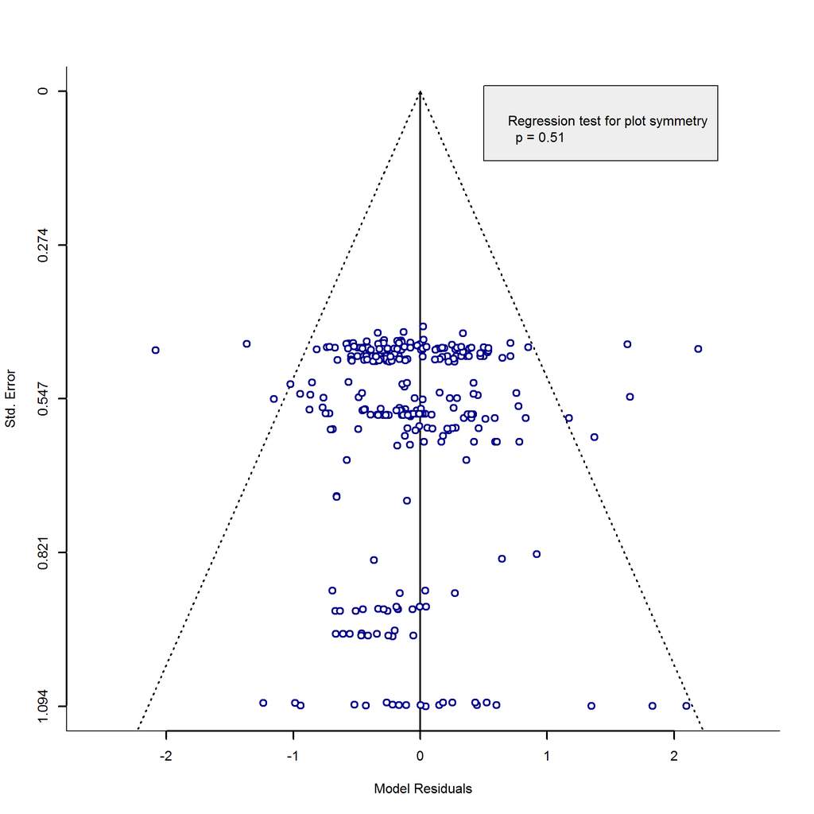

```r
funnel(res_full,
       back = "white",
       xlab = "Model Residuals",
       ylab = "Std. Error",
       pch = 21,
       col = "darkblue",
       cex = 1.1,
       lwd = 2
)
# Put eggers regression results on funnel plot
eggers_round <- round(eggers$pval, 2)
plt_text <- paste0("Regression test for plot symmetry \n\t\t  p = ", eggers_round, "\n\n")
legend(legend = plt_text, x = 0.5, y = -0.01, bg = alpha("darkgrey", 0.2))
```

*Output of Egger’s regression.*

```r
eggers$fit
```

```
##
## Call:
## lm(formula = yi ~ X - 1, weights = 1/vi)
##
## Weighted Residuals:
##      Min       1Q   Median       3Q      Max
## -14.9740  -1.0312  -0.2052   0.8569  17.3423
##
## Coefficients:
##      Estimate Std. Error t value Pr(>|t|)
## X    -0.12346    0.04217  -2.927  0.00369 **
## Xsei  0.15381    0.23167   0.664  0.50727
## ---
## Signif. codes:  0 '***' 0.001 '**' 0.01 '*' 0.05 '.' 0.1 ' ' 1
##
## Residual standard error: 2.466 on 294 degrees of freedom
## Multiple R-squared:  0.05028,    Adjusted R-squared:  0.04382
## F-statistic: 7.782 on 2 and 294 DF,  p-value: 0.0005091
```

# Sensibility analysis

## Pseudoreplication

Pseudoreplicated designs were widespread in our selected studies. Therefore, to determine the influence of effect size estimates from pseudoreplicated studies in our meta-analysis, we contrasted the effect size estimate for pseudoreplicated and non-pseudoreplicated studies. For this we conducted a meta-analysis with pseudoreplication as the single binary moderator and observed if the resulting estimate of the contrast between both designs overlapped zero.

*Meta-analysis with pseudoreplication moderator*

```r
no_out <- capture.output({
            df_pseudorep <-  clear_moderators(df_tidy, "pseudoreplication")
          })

res_pseudorep <- rma.mv(z, var, random = ~1 | id/entry, mods = ~ pseudoreplication,
                        data = df_pseudorep)
res_pseudorep
```

```
##
## Multivariate Meta-Analysis Model (k = 364; method: REML)
##
## Variance Components:
##
##             estim    sqrt  nlvls  fixed    factor
## sigma^2.1  0.0508  0.2254     34     no        id
## sigma^2.2  0.1754  0.4188    364     no  id/entry
##
## Test for Residual Heterogeneity:
## QE(df = 362) = 2176.1806, p-val < .0001
##
## Test of Moderators (coefficient 2):
## QM(df = 1) = 0.4077, p-val = 0.5231
##
## Model Results:
##
##                       estimate      se     zval    pval    ci.lb   ci.ub
## intrcpt                 0.3759  0.0713   5.2759  <.0001   0.2363  0.5156  ***
## pseudoreplicationYES   -0.0787  0.1232  -0.6385  0.5231  -0.3201  0.1628
##
## ---
## Signif. codes:  0 '***' 0.001 '**' 0.01 '*' 0.05 '.' 0.1 ' ' 1
```

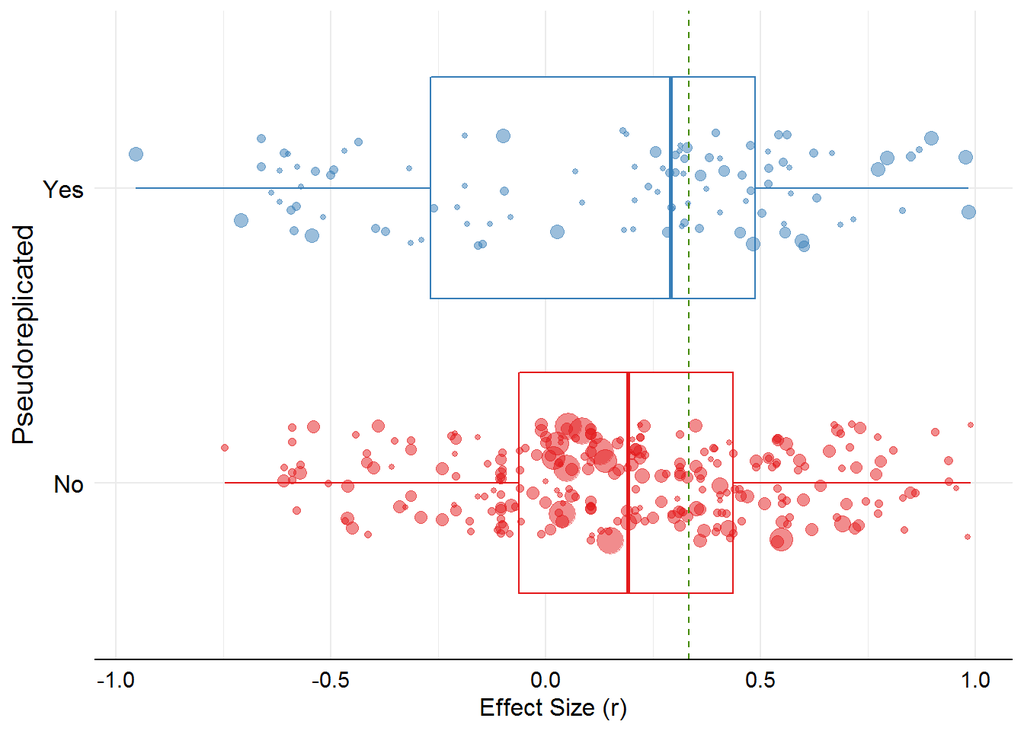

```r
ggplot(data = df_pseudorep, aes(x = pseudoreplication, y = z2r(z))) +
  geom_boxplot(aes(color = pseudoreplication)) +
  geom_jitter(aes(color = pseudoreplication, size = n), width = 0.2, alpha = 0.5) +
  geom_hline(yintercept = z2r(res_main$b), color = "chartreuse4", linetype = 2) +
  ylab("Effect Size (r)") +
  xlab("Pseudoreplicated") +
  scale_color_brewer(palette = "Set1") +
  scale_x_discrete(labels = c("No", "Yes")) +
  coord_flip() +
  theme_minimal() +
  theme(legend.position = "none",
        axis.text.y = element_text(size = 12, color = "black"),
        axis.text.x = element_text(size = 11, color = "black"),
        axis.title.y = element_text(size = 14),
        axis.title.x = element_text(size = 12),
        axis.line.x = element_line(color = "black")
  )
```

**Figure 6 -** Boxplot comparing effect size mean values of sampling designs considered pseudoreplicated (“Yes” on the vertical axis) against sampling designs not considered pseudoreplicated (“No” on the vertical axis). The circles represent each individual effect size mean value, and the circle size indicates the relative sample size of the effect size. The dashed green vertical line shows the position of summary effect size obtained from the intercept only meta-analysis.

We failed to find differences between the estimates of pseudoreplicated and non-pseudoreplicated designs. Thus, we believe that our adjustment of sample sizes, was a sufficient treatment for pseudoreplication in our meta-analysis.

## Outliers

We visually inspected the presence of outlier studies using Cook’s distance clustered by studies. The Cook’s distance for a given study, refers to how far, on average, effect size estimates will move if the study in question is dropped from model fitting (Viechtbauer & Cheung, 2010). We considered a study an outlier if its Cook’s distance was higher than the average of all computed Cook’s distances.

### Cook’s distance

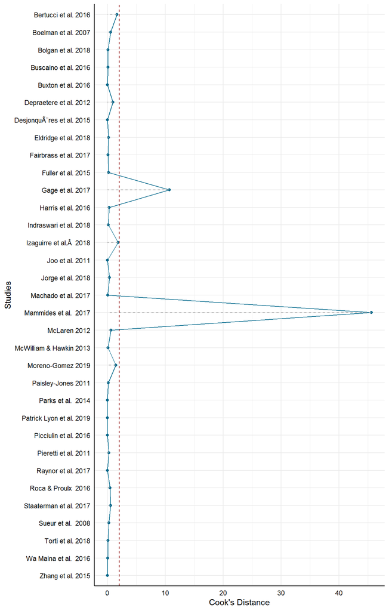

```r
### Cook's distances for each study!

cooks_dist <- cooks.distance(res_full, cluster=df_full$id)
df_full$id <- as.character(df_full$id)

df_cooks <- data.frame(id = names(cooks_dist), cooks_dist = cooks_dist)

df_cooks <- df_cooks %>%
              left_join(df_full, by = "id") %>%
              select(id, authors, cooks_dist)
# Remove leading spaces
df_cooks$authors <- str_remove(df_cooks$authors, "^\\s")
df_cooks <- df_cooks %>%
              filter(!duplicated(authors)) %>%
              arrange(authors)

ggplot(data = df_cooks, aes(x = authors, y = cooks_dist, group = 1)) +
  geom_point(color = "deepskyblue4") +
  geom_line(color = "deepskyblue4") +
  geom_segment(aes(xend=authors), yend = 0, color = "darkgrey", linetype = 2) +
  geom_hline(yintercept = mean(cooks_dist), color = "darkred", linetype = 2) +
  xlab("Studies") + ylab("Cook's Distance") +
  scale_x_discrete(limits = rev(df_cooks$authors)) +
  theme_minimal() +
  theme(
        axis.text = element_text(color = "black"),
        axis.line = element_line(color = "black"),
  ) +
  coord_flip()
```

**Supplementary Figure 7 -** Cook’s distance values for each study (blue dots on the figure) and average Cook’s distance over all studies indicated as a dashed vertical red line. The Cook’s distance for a given study can be interpreted as the distance between the entire set of predicted values once with this study included and once with the this study excluded from the model fitting procedure. On the y-axis are the studies identified by first author and year. The x-axis corresponds to the Cook’s distance values.

### Check outlier studies

Here, we examine outlier studies to discriminate possible reasons for their influence.

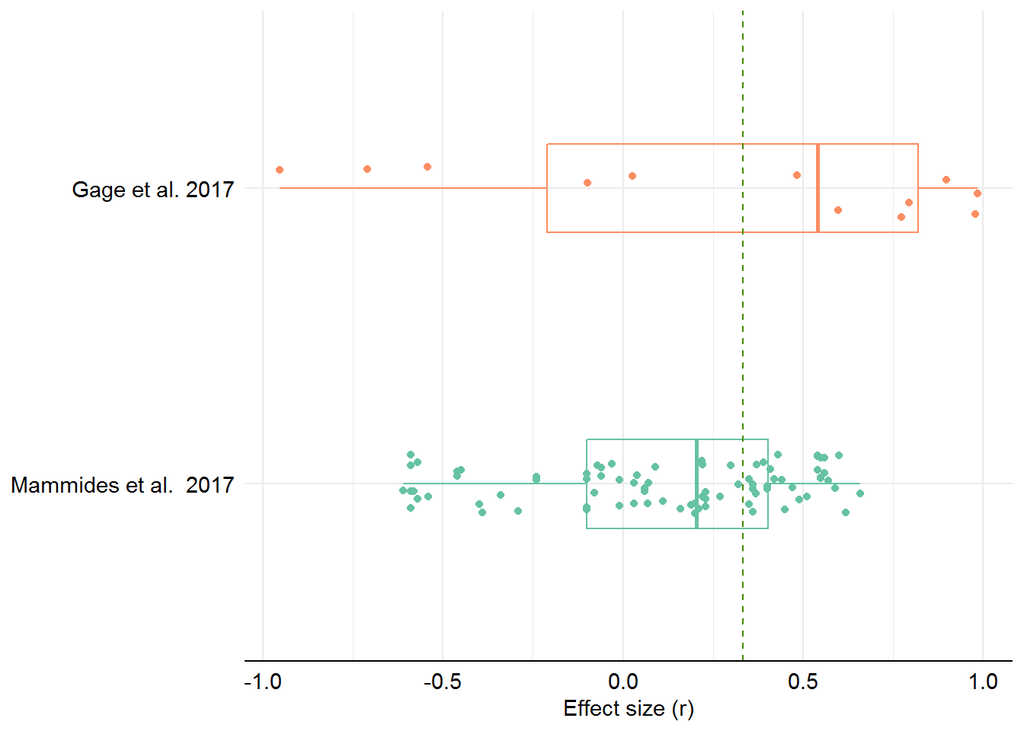

```r
outliers <- df_cooks[which(df_cooks$cooks_dist > mean(df_cooks$cooks_dist)), ]$id

df_outliers <- df_full[which(df_full$id %in% outliers), ]

ggplot(data = df_outliers, aes(x = z2r(z), y = id)) +
  geom_boxplot(aes(color = id), fill = NA, width = 0.3) +
  geom_jitter(height = 0.1, aes(color = id)) +
  scale_color_brewer(palette = "Set2") +
  scale_y_discrete(labels = rev(unique(df_outliers$authors))) +
  xlab("Effect size (r)") +
  geom_vline(xintercept = z2r(res_main$b), color = "chartreuse4", linetype = 2) +
  theme_minimal() +
  theme(
    axis.title.y = element_blank(),
    axis.text.y = element_text(size = 11, color = "black"),
    axis.text.x = element_text(size = 11, color = "black"),
    axis.line.x = element_line(color = "black"),
    legend.position = "none"
  )
```

**Supplementary Figure 8 -** Boxplot and distribution of of effect size values (dots) of the two studies identified as outliers. The y-axis identifies the study, and the x-axis corresponds to the Pearson r effect size. The green vertical dashed line is the summary effect obtained in the intercept-only model.

Both outlier studies used birds as the organism of study, and assessed multiple acoustic indices (Gage *et al.* (2017) examined ACI, ADI, AEI, BIO, H, NDSI indices; and Mammides *et al.* (2017) examined ACI, ADI, AEI, AR, BIO, H, NDSI indices). The main difference was that Gage *et al.* (2017) used acoustic recordings to get biodiversity measures while Mammides *et al.* (2017) relied on non acoustic sources of biodiversity information.

The box plots and effect size dispersion, suggest that the study by Gage *et al.* (2017) contributed overdispersed effect sizes values, including some at the lower and high ends of the Pearson effect size scale of (-1 to 1).

The Mammides *et al.* (2017) study contributed a total 84 effect sizes, also dispersed over a wide range. The number of effect sizes per se (23% of total effect sizes) could be responsible for its high value of Cook’s distance.

### Removing outlier studies and examining results

We evaluated the robustness of our results by removing the outliers from the dataset, and running the meta-regression model without the outlier studies.

*Meta-analysis with outliers removed*

```r
df_no_outliers <- df_full[-which(df_full$id %in% outliers), ]

res_no_outliers <- rma.mv(z, var, random = ~1 | id/entry,
                   mods = ~ index + bio + environ + diversity_source,
                   data = df_no_outliers)

res_no_outliers
```

```
##
## Multivariate Meta-Analysis Model (k = 200; method: REML)
##
## Variance Components:
##
##             estim    sqrt  nlvls  fixed    factor
## sigma^2.1  0.1225  0.3500     31     no        id
## sigma^2.2  0.0557  0.2360    200     no  id/entry
##
## Test for Residual Heterogeneity:
## QE(df = 188) = 472.4368, p-val < .0001
##
## Test of Moderators (coefficients 2:12):
## QM(df = 11) = 6.3074, p-val = 0.8521
##
## Model Results:
##
##                           estimate      se     zval    pval    ci.lb   ci.ub
## intrcpt                     0.6457  0.1870   3.4522  0.0006   0.2791  1.0123
## indexADI                   -0.2059  0.1118  -1.8412  0.0656  -0.4251  0.0133
## indexAEI                   -0.0753  0.1260  -0.5977  0.5500  -0.3224  0.1717
## indexAR                    -0.0770  0.2082  -0.3700  0.7114  -0.4850  0.3310
## indexBIO                   -0.0992  0.1192  -0.8319  0.4054  -0.3328  0.1345
## indexH                     -0.0357  0.1058  -0.3372  0.7360  -0.2430  0.1716
## indexNDSI                  -0.0164  0.1406  -0.1165  0.9073  -0.2919  0.2591
## bioabundance               -0.1566  0.1512  -1.0355  0.3005  -0.4530  0.1398
## biodiversity               -0.1064  0.1298  -0.8199  0.4122  -0.3607  0.1479
## biosound_abundance          0.1597  0.2105   0.7587  0.4480  -0.2528  0.5722
## environA                   -0.1907  0.2057  -0.9271  0.3539  -0.5939  0.2125
## diversity_sourceacoustic   -0.1379  0.1909  -0.7226  0.4700  -0.5120  0.2362
##
## intrcpt                   ***
## indexADI                    .
## indexAEI
## indexAR
## indexBIO
## indexH
## indexNDSI
## bioabundance
## biodiversity
## biosound_abundance
## environA
## diversity_sourceacoustic
##
## ---
## Signif. codes:  0 '***' 0.001 '**' 0.01 '*' 0.05 '.' 0.1 ' ' 1
```

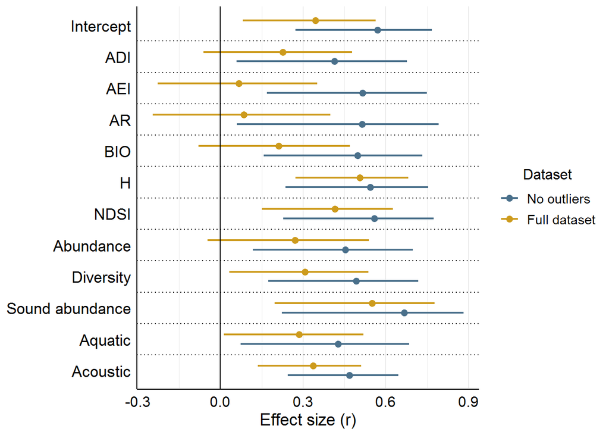

```r
# With outliers results from full model results
df_pred$df <- "with_outliers"
# No outliers resuls in dataframe
df_no_outliers_plt <- get_predictions(res_no_outliers)
df_no_outliers_plt$moderators <- df_pred$moderators
df_no_outliers_plt$coef <- factor(df_pred$coef,
                                  levels = rev(df_pred$coef))
df_no_outliers_plt$df <- "no_outliers"

df_examine_outliers <- rbind(df_pred, df_no_outliers_plt)

plt_colors <- c("skyblue4", "goldenrod3")#"seagreen")
pd <- position_dodge(0.6)
n_rows <- nrow(res_full$b)

ggplot(data = df_examine_outliers, aes(x = estimate, y = coef, color = df, position = df)) +
    geom_point(position = pd, size = 2.3) +
    geom_errorbarh(aes(xmin = ci.lb, xmax = ci.ub), height = 0, position = pd, size = 0.8) +
    geom_vline(xintercept = 0, linetype = 1, color = "black") +
    #scale_y_discrete(labels =  rev(y_labels)) +
    scale_color_manual(values = plt_colors, name = "Dataset",
                       labels = c("No outliers", "Full dataset")) +
    geom_hline(yintercept= seq(1, n_rows - 1) + 0.5, linetype = 3, color = "black") +
    theme_minimal() +
    xlab("Effect size (r)") +
    theme(axis.text.x = element_text(size = 12, color = "black"),
          axis.text.y = element_text(size = 13, color = "black"),
          axis.line.x = element_line(color = "black"),
          axis.line.y = element_line(color = "black"),
          axis.title.y = element_blank(),
          axis.title.x = element_text(size = 14),
          panel.grid.major.y = element_blank(),
          legend.title = element_text(hjust = 0.5, size = 12),
          legend.text = element_text(size = 11)
    )
```

**Figure 4c -** Contrast of model estimates obtained with meta-regression analysis over the full dataset (yellow) and over the dataset with outliers removed (blue). Mean estimates are represented with circles and corresponding 95% confidence intervals with horizontal lines. We considered outliers every study that had a Cook’s distance value higher than the mean of all Cook distances. Model moderators were acoustic indices (ADI, AEI, AR, BIO, H, NDSI, with ACI as intercept), diversity metric (Abundance, Diversity, Sound abundance, with Richness as intercept), environment (Aquatic, with Terrestrial as intercept), diversity source (Acoustic, with Non-Acoustic as intercept). The solid vertical black line represents a null effect size.

The results are similar with major overlap between confidence intervals, specially for the most conclusive results in the full dataset. It seems that removing outliers had a tendency to generate stronger mean effect size estimates of the correlation between acoustic indices and biodiversity.

*Heterogeneity for the intercept-only model with no outliers*

```r
res_main_no_outliers <- rma.mv(z, var, random = ~1 | id/entry, data = df_no_outliers)

Is_no_outliers <- multilevel_I(res_main_no_outliers)

sum(Is_no_outliers)
```

```
## [1] 0.8256989
```

## Effect size tendencies

We visually inspected tendencies in the effect size over year of publication, and impact factor of the journal.

### Publication year

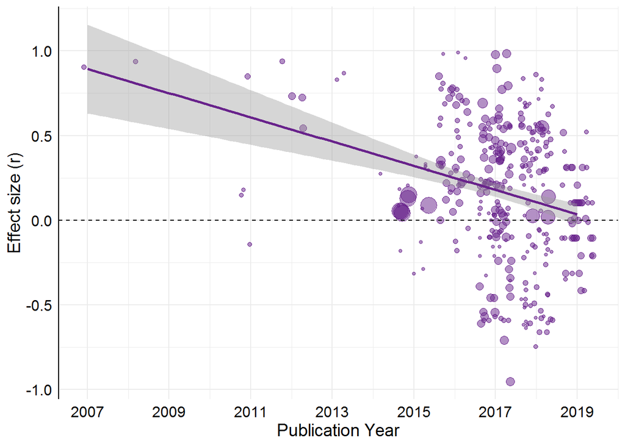

```r
plt_color <- "darkorchid4"
ggplot(df_tidy, aes(x = year, y = z2r(z))) +
    geom_jitter(aes(size = n), shape = 21,
                fill = alpha(plt_color, 0.5),
                color = plt_color) +
    geom_hline(yintercept=0, linetype = 2) +
    geom_smooth(method='lm', color = plt_color) +
    labs(y = "Effect size (r)", x = "Publication Year") +
    scale_x_continuous(breaks = seq(min(df_tidy$year),
                                    max(df_tidy$year), by = 2)) +
    theme_minimal() +
    theme(
        axis.line.y = element_line(color = "black"),
        axis.text = element_text(color = "black", size = 12),
        axis.title = element_text(color = "black", size = 14),
        legend.position = "none"
    )
```

**Figure 7a -** Relation between effect size mean values (circles) and publication year. Circle size indicates the relative sample size of each effect size. The fitted line is a simple least squares regression with the corresponding 95% confidence interval region in grey. The dashed horizontal line represents an effect size of 0. Effect size mean values are positioned along the publication year axis with minor random noise to reduce overlapping.

### Publication year > 2015

Fitting a regression line over studies from 2015 to 2019, the decreasing tendency persists but it is less pronounced.

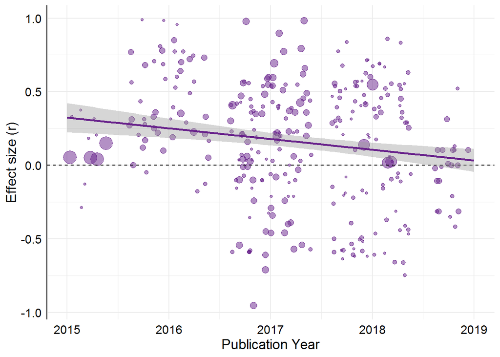

```r
df_tidy_after2015 <- df_tidy[df_tidy$year >= 2015, ]

ggplot(df_tidy_after2015, aes(x = year, y = z2r(z))) +
    geom_jitter(aes(size = n), shape = 21,
                fill = alpha(plt_color, 0.5),
                color = plt_color) +
    geom_hline(yintercept=0, linetype = 2) +
    geom_smooth(method='lm', color = plt_color) +
    labs(y = "Effect size (r)", x = "Publication Year") +
    scale_x_continuous(limits = c(2015, 2019),
                       breaks = seq(min(df_tidy_after2015$year),
                                    max(df_tidy_after2015$year),
                                    by = 1)) +
    theme_minimal() +
    theme(
        axis.line.y = element_line(color = "black"),
        axis.text = element_text(color = "black", size = 12),
        axis.title = element_text(color = "black", size = 14),
        legend.position = "none"
    )
```

**Figure 7b -** Relation between effect size mean values (circles) and publication year after 2015 (inclusive) where there is a sudden and prominent rise of publications. Circle size indicates the relative sample size of each effect size. The fitted line is a simple least squares regression with the corresponding 95% confidence interval region in grey. The dashed horizontal line represents an effect size of 0. Effect size mean values are positioned along the publication year axis with minor random noise to reduce overlapping.

### Impact factor

Effect size values do not appear to exhibit a tendency when it comes to journal impact factor.

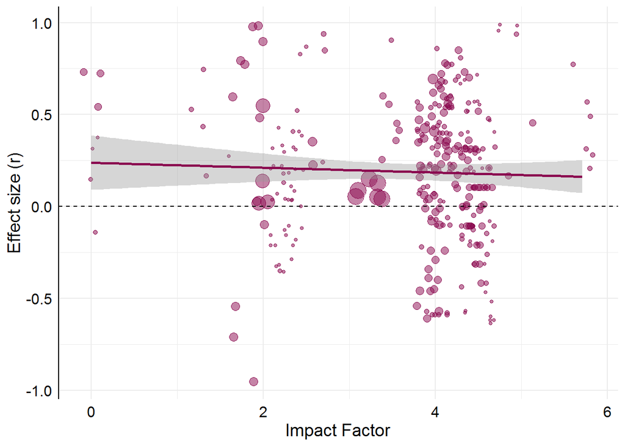

```r
plt_color <- "deeppink4"
ggplot(df_tidy, aes(x = impact_factor, y = z2r(z))) +
  geom_jitter(aes(size = n), shape = 21,
              fill = alpha(plt_color, 0.5),
              color = plt_color,
              width = 0.2) +
    geom_hline(yintercept=0, linetype = 2) +
    geom_smooth(method='lm', color = plt_color) +
    labs(y = "Effect size (r)", x = "Impact Factor") +
    theme_minimal() +
    theme(
        axis.line.y = element_line(color = "black"),
        axis.text = element_text(color = "black", size = 12),
        axis.title = element_text(color = "black", size = 14),
        legend.position = "none"
    )
```

**Supplementary Figure 9 -** Relation between effect size mean values (circles) and journal impact factor. Circle size indicates the relative sample size of each effect size. The fitted line is a simple least squares regression with the corresponding 95% confidence interval region in grey. The dashed horizontal line represents an effect size of 0. Effect size mean values are positioned along the impact factor axis with minor random noise to reduce overlapping.

# Supplementary data

All code files and supplementary data used in the study can be found in https://irene-alcocer.github.io/Acoustic-Indices/.

# References

Buxton, R., Agnihotri, S., Robin, V., Goel, A. & Balakrishnan, R. (2018a) Acoustic indices as rapid indicators of avian diversity in different land-use types in an indian biodiversity hotspot. *Journal of Ecoacoustics* **2**, 1–17.

Buxton, R.T., McKenna, M.F., Clapp, M., Meyer, E., Stabenau, E., Angeloni, L.M., Crooks, K. & Wittemyer, G. (2018b) Efficacy of extracting indices from large-scale acoustic recordings to monitor biodiversity. *Conservation Biology* **32**, 1174–1184. Wiley Online Library.

Del Re, A. & Del Re, M.A. (2012) Package ‘compute. Es’. https://cran.r-project.org/web/packages/compute.es/index.html.

Gage, S.H., Wimmer, J., Tarrant, T. & Grace, P.R. (2017) Acoustic patterns at the samford ecological research facility in south east queensland, australia: The peri-urban supersite of the terrestrial ecosystem research network. *Ecological Informatics* **38**, 62–75. Elsevier.

Koricheva, J., Gurevitch, J. & Mengersen, K. (2013) *Handbook of meta-analysis in ecology and evolution*. Princeton University Press.

Mammides, C., Goodale, E., Dayananda, S.K., Kang, L. & Chen, J. (2017) Do acoustic indices correlate with bird diversity? Insights from two biodiverse regions in yunnan province, south china. *Ecological Indicators* **82**, 470–477. Elsevier.

Nakagawa, S. & Cuthill, I.C. (2007) Effect size, confidence interval and statistical significance: A practical guide for biologists. *Biological reviews* **82**, 591–605. Wiley Online Library.

Rohatgi, A. (2019) WebPlotDigitizer, version 4.2. https://apps.automeris.io/wpd/.

Sueur, J., Farina, A., Gasc, A., Pieretti, N. & Pavoine, S. (2014) Acoustic indices for biodiversity assessment and landscape investigation. *Acta Acustica united with Acustica* **100**, 772–781. S. Hirzel Verlag.

Sugai, L.S.M., Silva, T.S.F., Ribeiro Jr, J.W. & Llusia, D. (2019) Terrestrial passive acoustic monitoring: Review and perspectives. *BioScience* **69**, 15–25. Oxford University Press.

Viechtbauer, W. & Cheung, M.W.-L. (2010) Outlier and influence diagnostics for meta-analysis. *Research synthesis methods* **1**, 112–125. Wiley Online Library.

Viechtbauer, W., López-López, J.A., Sánchez-Meca, J. & Marı́n-Martı́nez, F. (2015) A comparison of procedures to test for moderators in mixed-effects meta-regression models. *Psychological methods* **20**, 360. American Psychological Association.

Zuur, A.F., Ieno, E.N. & Elphick, C.S. (2010) A protocol for data exploration to avoid common statistical problems. *Methods in ecology and evolution* **1**, 3–14. Wiley Online Library.